← Richard Hoffmann

# Can a video model tell which of its own futures to trust?

TLDR: Using a video diffusion model's own denoising dynamics to pick more physically accurate samples, mid-generation.

**Richard Hoffmann** with [Sarah Liaw](https://sarahliaw.github.io/), [Ruojin Cai](https://ruojincai.github.io/), [Yilun Du](https://yilundu.github.io/) November 1, 2026 Reading time ~20 minutes

When you query a video model multiple times with the same prompt, it may generate varying outputs every time. In fact, give a video model the same first frame ten times to condition on, and you will get ten different futures back. Some are more physically plausible than others. Some produce videos where objects duplicate or morph something that was never there. The most straightforward way to address this issue is to choose among completed videos: for every input, generate K videos and ask an external judge to evaluate. This work proposes an alternative, where we ask the model *itself*, partway through generation, which of its candidate futures it can reconstruct most reliably, and continue generation with those.

For those skimming the post, the short version is that the model's own denoising process does carry some information about how a sample will turn out, well before the video is done. We found a way to read it, turned it into a small inference-time algorithm called **Noise-Play**, and tested it on two video generators. While we did see improvements in various scoring metrics, the effects are modest. However the idea is cheap, needs no training and no external verifier, and I think it shows that we should investigate the denoising process more thoroughly.

## Same input, different futures

Let's start with a concrete example. Physics-IQ[1] is a benchmark built from real physical scenarios, designed to test whether generative video models understand physical principles. It does this by directly comparing generated outputs against real ground-truth videos for every scenario. In one specific episode, a tennis ball rolls out of a pipe onto a table where two other balls are already resting. We give a frozen LTX-2.3 model the opening of that episode (first 3 seconds) plus a prompt, and sample eight videos from eight different noise seeds. We show 4 of them below.

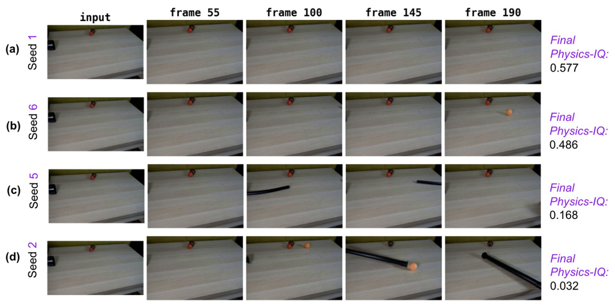

**Figure 1. Same conditioning, different outputs.** Four of eight independent rollouts from a frozen LTX-2.3 video model, all conditioned on the identical first frame and prompt. The final Physics-IQ score of each is on the right.

In the top row, no ball ever leaves the pipe and the rest of the scene stays static. In the second, a ball does appear, but then duplicates. In the bottom two, the pipe and the environment morph in ways that no physical table would allow, and those get the lowest scores by a wide margin: 0.168 and 0.032, against 0.577 and 0.486.

Video models are increasingly used as *world models*: generated futures stand in for the consequences of a robot's actions, to train or evaluate policies without touching the real world[2][3][4]. A useful world model has to do more than produce a convincing video. It has to preserve objects, respect geometry and physics, and stay consistent with what it was told. And if the quality varies this much from seed to seed, then *deciding which sample to trust* is as important as being able to generate one at all.

## An alternative to Best-of-K

The standard approach is best-of-K: initialize K independent samples, score each completed video with an external reward model or verifier (often a video-language model acting as a judge), and select the highest scoring final video[5]. While this approach works, there are two issues to consider.

1. **Errors.** Best-of-K inherits the biases and errors of a learned verifier, which are then propagated. These may not match those of the generator[6][7].
2. **Full mid-generation.** Best-of-K needs all K videos completed *and decoded* before it can choose. Most of that compute goes to samples that just ended up being tossed at the end.

A handful of recent works ask whether the generator itself can supply a useful signal[8][9][10]. Proprio[8], for example, uses the model's own flow residual to score samples. This leads us to our motivating question:

> Before generation is complete, does a video model's own denoising process reveal which of its stochastic futures will ultimately be more reliable?

Let's start with a simple observation. Take the four trajectories from Figure 1 and stop them 40% of the way through denoising. At that point, the model's current guess of the final video is a blurry smudge, which is not really interpretable for a human or VLM to judge. Then, keep its current guess of the clean video fixed, but perturb it using noise directions that come from the *other* initialized trajectories. Then measure how much the model's prediction changes. We call the result a sample's *noise value*.

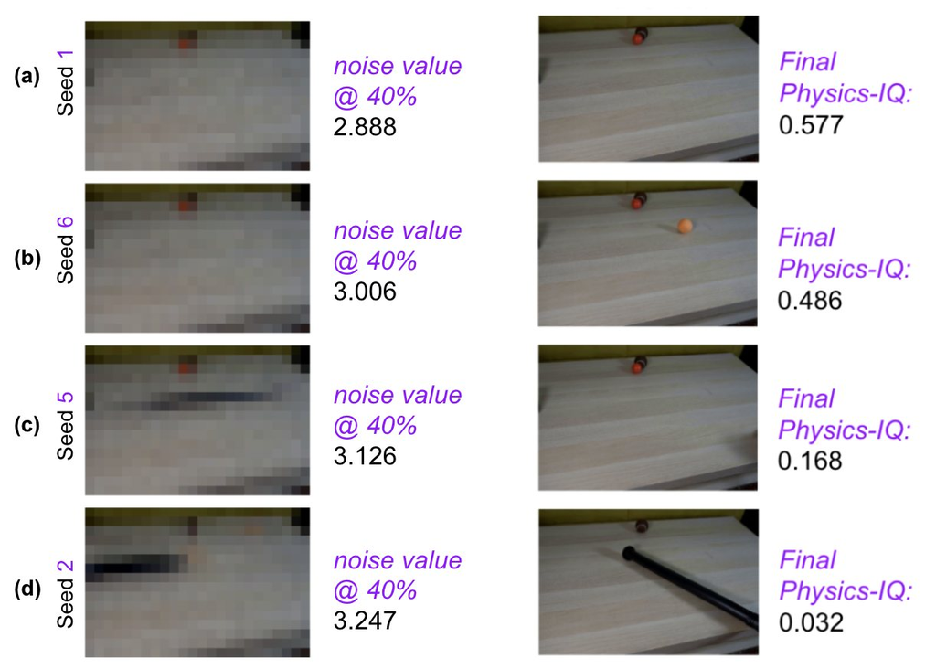

**Figure 2. Samples at 40% denoising.** Left: the model's intermediate prediction and its noise value. Right: the final frame and Physics-IQ score. Lower noise value goes with a higher final score, in the same order, before the final videos exist.

For this specific example, the ordering lines up perfectly: 2.888 < 3.006 < 3.126 < 3.247 against final scores of 0.577 > 0.486 > 0.168 > 0.032. The differences are small, but they are ordered the right way around, which is what ultimately matters. Of course, this is just an anecdotal episode, but we diagnose this observation and turn it into something we can measure at scale.

## Noise-value: how stable is a future?

Intuitively, you can think of our idea as a stress test for candidate futures. Suppose a model is partway through denoising and has a guess y for the final video. At this point you can ask: *if I keep your guess but swap in a different noise, do you come back to the same answer?* If y is something the model itself represents robustly, it should. If y was a a more fragile sample from the denoising basin, it should come back with greater difference.

### Set up

We use the standard flow matching formulation where where the noisy state is an interpolation between a noise endpoint z and a clean video latent y:

x<sub>t</sub> = α<sub>t</sub>z + β<sub>t</sub>y, α<sub>t</sub> + β<sub>t</sub> = 1,

and let f<sub>θ</sub>(x<sub>t</sub>, t) be the model's prediction of the clean endpoint. We use the other samples initialized as a source for new perturbation noise. If we are running K trajectories in parallel from different seeds, then at time t trajectory k has a state x<sub>t</sub><sup>(k)</sup> and proposes a clean endpoint y<sub>k</sub> = f<sub>θ</sub>(x<sub>t</sub><sup>(k)</sup>, t). Rearranging the interpolation gives the noise that trajectory implies,

ẑ<sub>k</sub> = (x<sub>t</sub><sup>(k)</sup> − β<sub>t</sub>y<sub>k</sub>) / α<sub>t</sub>.

Those require no extra sampling and no extra forward pass. To perturb candidate k with trajectory j, we keep y<sub>k</sub> and replace its noise with ẑ<sub>j</sub>, then let the model denoise:

x<sub>t</sub><sup>k←j</sup> = α<sub>t</sub>ẑ<sub>j</sub> + β<sub>t</sub>y<sub>k</sub>, y<sub>k←j</sub> = f<sub>θ</sub>(x<sub>t</sub><sup>k←j</sup>, t).

[figure not shown]

**Figure 3. The counterfactual noise perturbation.** Candidate k keeps its clean proposal (brown) but receives the noise (blue) implied by peer j. The model denoises the swapped state once, and we measure how far its new prediction drifts from the original.

Definition: noise-value

For a clean latent y and a noise direction z, let ŷ = f<sub>θ</sub>(α<sub>t</sub>z + β<sub>t</sub>y, t). The noise-value of y at time t is the expected reconstruction error

R<sub>t</sub>(y) = 𝔼<sub>z∼q</sub>[ dist(y, ŷ) ],

where q is a distribution over counterfactual noise directions.

A small R<sub>t</sub> means the model tends to return to roughly the same clean future when approached from other noise directions.

**What is this actually measuring? (a short derivation)**

The challenged state is the candidate's own state shifted by Δ<sub>kj</sub> = α<sub>t</sub>(ẑ<sub>j</sub> − ẑ<sub>k</sub>). A first-order Taylor expansion of the denoiser around the candidate's state gives

f<sub>θ</sub>(x<sub>t</sub><sup>(k)</sup> + Δ<sub>kj</sub>, t) − y<sub>k</sub> = J<sub>k</sub>Δ<sub>kj</sub> + O(‖Δ<sub>kj</sub>‖²),

where J<sub>k</sub> is the Jacobian of the denoiser at that state. Squaring and averaging over challengers gives 𝔼‖J<sub>k</sub>Δ<sub>kj</sub>‖² = 𝔼[Δ<sub>kj</sub><sup>⊤</sup>J<sub>k</sub><sup>⊤</sup>J<sub>k</sub>Δ<sub>kj</sub>] = 𝔼 tr(J<sub>k</sub><sup>⊤</sup>J<sub>k</sub> Δ<sub>kj</sub>Δ<sub>kj</sub><sup>⊤</sup>).

So, to first order, the reconstruction error is the endpoint sensitivity of the denoiser at that candidate, along the directions its peers' noise points. A candidate is "stable" when the model's clean prediction barely responds to those perturbations. That is the local-stability reading of noise-value, and it is why we describe the signal as the stability of a future under the model's own dynamics.

## Predicting physical plausibility

The test we care about at this point is whether noise-value, measure early, can tell us anything about how physically plausibile a finished video will be. For each of the 198 Physics-IQ scenarios we start K = 8 independent trajectories from the same conditioning. At checkpoints 20%, 40%, 60% and 80% of the way through denoising, we compute an internal score for every trajectory, using both Noise-Play and Proprio[8]. Then we completely generate all 8 videos and score them with Physics-IQ, which serves as the oracle.

We compare each internal ranking against the oracle ranking in two ways: the Spearman rank correlation, and the pairwise accuracy, i.e. the fraction of candidate pairs where the internal score correctly says which video will score higher.

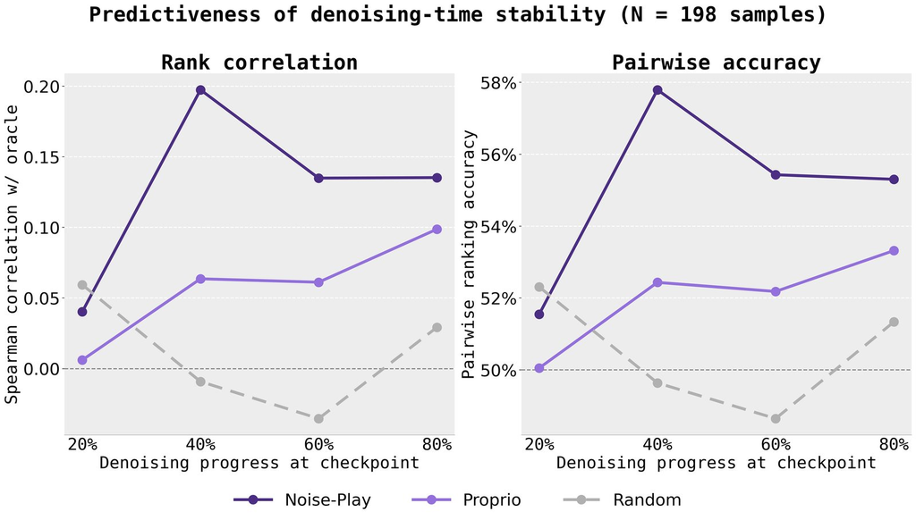

**Figure 4a. LTX-2.3.** Predictiveness of internal scores against the final Physics-IQ ranking, N = 198 scenarios, K = 8 trajectories each.

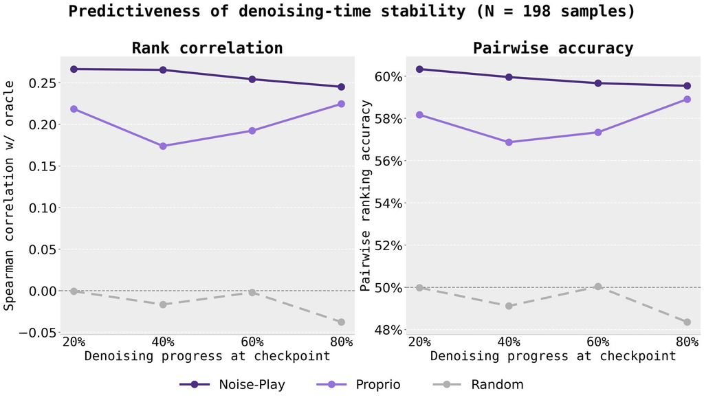

**Figure 4b. HunyuanVideo-1.5.** Same protocol on a second generator.

On LTX-2.3, the signal is strongest around 40% of the way through denoising. There Noise-Play reaches a Spearman correlation of about 0.20 with the eventual Physics-IQ score and ranks a pair correctly 57.8% of the time, while Proprio sits near 52%. After that the signal stays positive but weakens. On HunyuanVideo-1.5 the picture is different in shape: Noise-Play stays above Proprio at every checkpoint, with a flatter profile. The random scorer hovers around zero in both, as it should.

It's important to note that a correlation of 0.20 is weak. The oracle outcome is noisy and most of its variance is not explained by this signal. What it does establish is that the signal is real, that it shows up on two different generators, and that it is present substantially before generation is complete. One reading is that there is an intermediate regime where candidate futures have already acquired enough structure to differ in stability, but haven't yet fully committed.

## From diagnostic to algorithm

If stability measured mid-generation is informative, the obvious move is to use it to prune. For our algorithm, that means run K trajectories in parallel; at a few chosen noise levels let them challenge each other, drop the ones the model defends worst, and spend the remaining compute on the survivors.

For each candidate k in a round, we define its *defense error* as the average distance between its original proposal and its challenged reconstructions, over all K<sub>r</sub> − 1 peers:

E<sub>k</sub> = 1/(K<sub>r</sub> − 1) · Σ<sub>j≠k</sub> d(ŷ<sub>k</sub>, ŷ<sub>k←j</sub>).

Algorithm: Noise-Play (inference-time selection)

Input: conditioning *c*, *K* seeds, *R* rounds, survivor counts *K*<sub>1</sub> = *K* > *K*<sub>2</sub> > … > 1

Sample *K* independent noises; start *K* trajectories

for round *r* = 1 … *R*:

advance every active trajectory to noise level *t<sub>r</sub>*, and predict its clean endpoint *ŷ<sub>k</sub>*

for each active *k*, for each other active *j*:

infer *j*'s noise *ẑ<sub>j</sub>*; build *x<sup>k←j</sup>* = *α ẑ<sub>j</sub>* + *β ŷ<sub>k</sub>*; re-denoise to *ŷ<sub>k←j</sub>*

*E<sub>k</sub>* ← mean over *j* of *d*(*ŷ<sub>k</sub>*, *ŷ<sub>k←j</sub>*)

keep the *K*<sub>*r*+1</sub> trajectories with the smallest *E<sub>k</sub>*; resume them from their own states

finish denoising the surviving trajectory and decode

In our LTX-2.3 runs we used K = 4 with two rounds: a first at step 16 of the model's 30-step schedule that cuts four trajectories to two, and a second at step 23 that picks the final one. (These step indices are hyperparameters tied to LTX-2.3's schedule, not constants) The picture:

[figure not shown]

**Figure 5. Noise-Play as an inference-time selector (K = 4).** All trajectories run in parallel until the first round; the two with the highest defense error are pruned and never finish. The remaining two face a second round, and only the survivor is denoised to the end and decoded.

## Does it help?

We evaluated Noise-Play on three notions of sample quality: physical plausibility on Physics-IQ[1], temporal motion consistency on WorldScore-Dynamic[11], and 3D geometric consistency on WorldScore-Static. For each metric we compare the Noise-Play-selected rollout against a single-seed baseline. We use two generators: LTX-2.3 in a video-to-video setting and HunyuanVideo-1.5 in an image-to-video setting.

| Setting | Metric | Single seed | Noise-Play | Δ |
| --- | --- | --- | --- | --- |
| **LTX-2.3** v2v | Physics-IQ ↑ | 42.7 | 43.6 | +0.9 |
|  | Physics-IQ Verified ↑ | 42.0 | 43.1 | +1.1 |
| **HunyuanVideo-1.5** i2v | Physics-IQ ↑ | 25.9 | 27.3 | +1.4 |
|  | Physics-IQ Verified ↑ | 26.7 | 28.2 | +1.5 |

**Table 1. Physics-IQ.** Noise-Play uses only the frozen generator's own denoising dynamics for selection.

The Physics-IQ gains are modest, around one point on a scale where the models sit at 26 to 43, but they point the same way for both generators and both versions of the benchmark. WorldScore results are similar, with larger relative gains on the geometric metric:

| Model | Metric | Single seed | Noise-Play | Δ |
| --- | --- | --- | --- | --- |
| **LTX-2.3** | Dynamic pairwise pref. ↑ | – | 54.7% | +4.7 pp |
|  | Dynamic motion smoothness (SSIM) ↑ | 0.9337 | 0.9350 | +0.14% |
|  | Static pairwise pref. ↑ | – | 54.4% | +4.4 pp |
|  | Static reprojection error ↓ | 0.353 | 0.310 | −12.2% |
| **HunyuanVideo-1.5** | Dynamic pairwise pref. ↑ | – | 68.1% | +18.1 pp |
|  | Dynamic motion smoothness (SSIM) ↑ | 0.9776 | 0.9818 | +0.43% |
|  | Static pairwise pref. ↑ | – | 66.4% | +16.4 pp |
|  | Static reprojection error ↓ | 0.319 | 0.244 | −23.5% |

**Table 2. WorldScore.** Pairwise preference is the fraction of scenes where the Noise-Play-selected rollout beats the single-seed baseline; its Δ is in percentage points above the 50% chance level.

Pairwise preference over the baseline is 54.7% (dynamic) and 54.4% (static) for LTX-2.3. For HunyuanVideo-1.5 it is 68.1% and 66.4%, which is a larger gap. Static-scene reprojection error, which measures how well the video's geometry holds together across views, drops by 12.2% on LTX-2.3 and 23.5% on HunyuanVideo-1.5. Motion smoothness improves only modestly for both. Since the selection criterion is identical across generators and across these quite different notions of quality, we interpret this as evidence that the signal is picking up something about coherence in general, rather than something specific to Physics-IQ.

### Qualitative examples

Here are two WorldScore-Static episodes, in which the camera orbits a scene that should otherwise stay still. Notice how the single-seed LTX-2.3 library drifts and rearranges itself as the camera moves, and how much steadier the Noise-Play pick is. Similarly with the Hunyuan example, the single seed baseline actually morphs the room, putting the chairs away from the wall, while the Noise-Play selected rollouts keeps the room more intact.

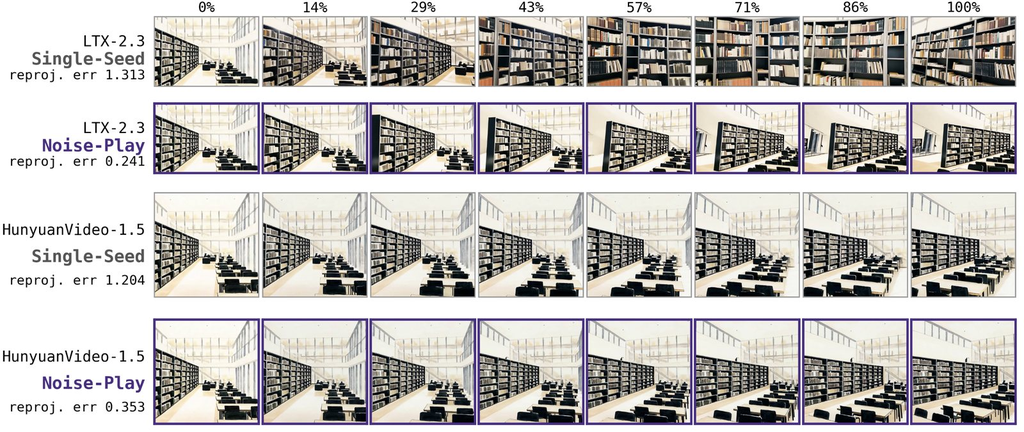

**Figure 6. WorldScore-Static, episode 0230.** "In the Modern Library, sunlight streams through skylights…" Lower reprojection error is better. LTX-2.3: 1.313 → 0.241. HunyuanVideo-1.5: 1.204 → 0.353.

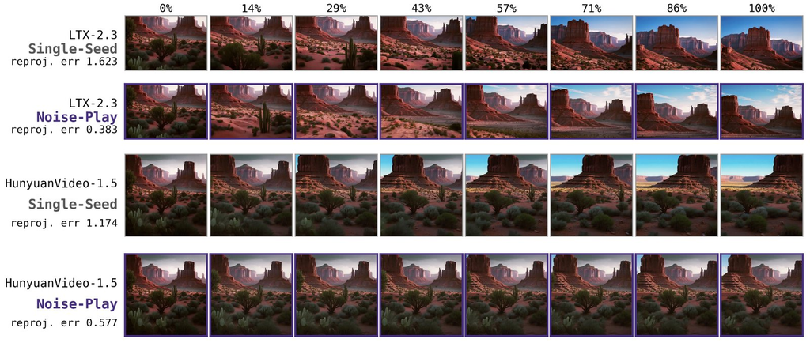

**Figure 7. WorldScore-Static, episode 0320.** "Monument Valley Landscape: vast desert terrain with iconic buttes…" LTX-2.3: 1.623 → 0.383. HunyuanVideo-1.5: 1.174 → 0.577.

## Controlled comparison

The previous section compares Noise-Play against a single seed. To test against Proprio, another internal-scoring method, for each of the 198 scenarios of Physics-IQ Verified[12], three selectors receive the *exact same* K = 4 noise initializations and differ only in how they choose the survivor: **Random** (no quality signal), **Proprio** (the model's own flow residual) and **Noise-Play** (noise-value across the seeds). Only the chosen trajectory is continued and decoded.

#### Physics-IQ Verified ↑

Random

40.3

Proprio

44.8

**Noise-Play**

44.8

#### Time per scenario (seconds) ↓

Random

280.1

Proprio

349.6

**Noise-Play**

301.7

**Figure 8. Controlled K = 4 selection.** Identical candidate pools for every selector. Left axis spans 0 to 50, right axis 0 to 400 s.

Random selection gets 40.3. Both Noise-Play and Proprio get 44.8. The internal signal beats an uninformed choice from the same pool, and the two internal signals are indistinguishable on average.

### Noise-Play vs Proprio

The tie is also pretty interesting. Noise-Play and Random pick different trajectories in 159 of the 198 scenarios. In those cases, the Noise-Play pick averages 44.5 against Random's 38.8. Excluding two ties, Noise-Play's pick scores higher in 106 of the 157 decisive disagreements, a 67.5% rate. So when the signal actually changes which seed gets chosen, the change more often than not helps.

Noise-Play and Proprio disagree in 101 scenarios, 99 of them decisive. Noise-Play wins 45 of those: 45.5%, with p = 0.42, which is essentially a coin toss.

#### Win rate of the Noise-Play pick when selectors disagree

vs. Random  
106 of 157

chance

67.5%

vs. Proprio  
45 of 99

45.5%

**Figure 9. Decisive disagreements only.** Axis spans 0 to 100%. The dashed line marks chance.

### What it costs

Proprio probes consistency by sampling ε several times and evaluating its flow residual at those perturbed states, for each candidate. Noise-Play can instead stop a sample mid-generation at the challenge steps. End to end, Random takes 280.1 s per scenario, Proprio 349.6 s, and Noise-Play 301.7 s. This is a 13.7% reduction relative to Proprio at the same quality, and a small premium over Random (about 8%) for +4.49 points. Random is still the cheapest, but it uses no quality signal at all.

## Closing thoughts

When working in the space of video generation, it's easy to treat the denoising process as black box. It's interesting that we can use a diffusion model's randomness to our advantage, instead of just accepting it as a byproduct of the process. Independently initialized trajectories turn out to carry information in a way that can challenge other samples, and figure out what futures the model represents most stably to an extent.

It was also really fun just trying out different video models and seeing them break on different benchmarks and evals. To get really useful embodied AI and reliable world models, video generative models will have to encode a very strong understanding of the world's physical principles and output visually realistic and physically accurate futures.

**About this post.** This is joint work with Sarah Liaw, Ruojin Cai, advised by Yilun Du, supported by Caltech and the Kempner Institute at Harvard.

## References

1. Saman Motamed, Laura Culp, Kevin Swersky, Priyank Jaini, Robert Geirhos. Do generative video models understand physical principles? 2026.
2. Sherry Yang, Ofir Nachum, Yilun Du, Jason Wei, Pieter Abbeel, Dale Schuurmans. Foundation models for decision making: Problems, methods, and opportunities. 2023. https://arxiv.org/abs/2303.04129
3. Boyuan Chen et al. Large video planner enables generalizable robot control. 2026. https://arxiv.org/abs/2512.15840
4. Gemini Robotics Team et al. Evaluating Gemini robotics policies in a Veo world simulator. 2026. https://arxiv.org/abs/2512.10675
5. Fangfu Liu et al. Video-T1: Test-time scaling for video generation. 2025. https://arxiv.org/abs/2503.18942
6. Audrey Huang et al. Is best-of-n the best of them? Coverage, scaling, and optimality in inference-time alignment. 2025. https://arxiv.org/abs/2503.21878
7. Ming Liu, Wensheng Zhang. Is your video language model a reliable judge? 2025. https://arxiv.org/abs/2503.05977
8. Mariam Hassan, Kaouther Messaoud, Wuyang Li, Alexandre Alahi. Proprio: Latent self-scoring and inference-time refinement for physically plausible video generation. 2026. https://arxiv.org/abs/2605.28230
9. Sangwon Jang et al. Self-refining video sampling. 2026. https://arxiv.org/abs/2601.18577
10. Haoxuan Wu et al. Through the prism: Preference representation in intermediate states of video diffusion models. 2026. https://arxiv.org/abs/2606.20310
11. Haoyi Duan, Hong-Xing Yu, Sirui Chen, Li Fei-Fei, Jiajun Wu. WorldScore: A unified evaluation benchmark for world generation. 2025. https://arxiv.org/abs/2504.00983
12. Tim Rädsch et al. Physics-IQ verified. arXiv:2606.18943, 2026. https://arxiv.org/abs/2606.18943